# SISBID3: Cross Validation

R version

## 1 Cross-Validation

We begin by loading the `ISLR` package and examining the dimensions of the `Auto` data set.

```r
library(ISLR)
ncol(Auto)
```

```
## [1] 9
```

```r
nrow(Auto)
```

```
## [1] 392
```

## 2 Plot data

Often times, it’s good to practice to plot the data you are trying to analyze.This gives you a sense of whether there are outlier, interesting patterns, etc. These can motivate the model you end up fitting.

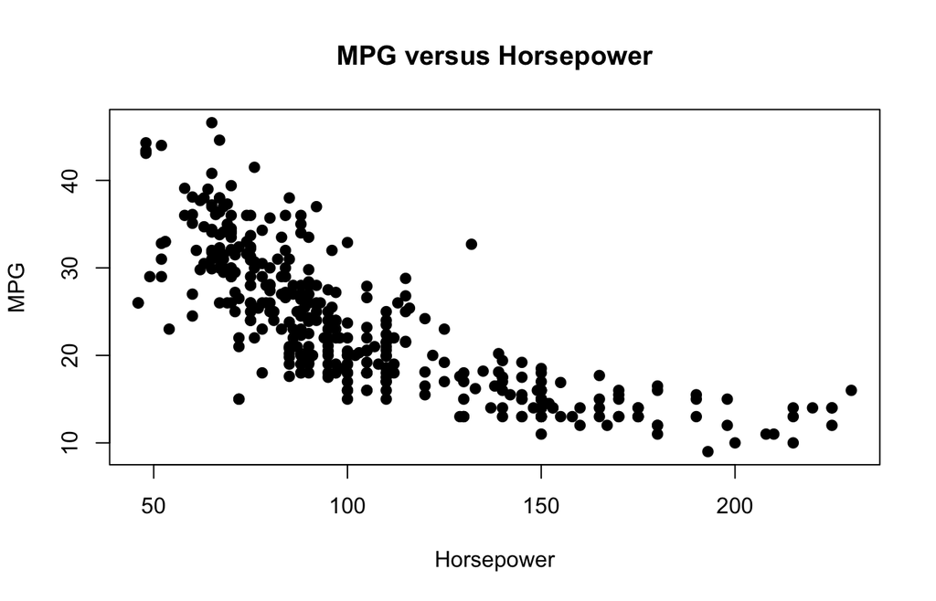

```r
set.seed(1)
train=sample(392,196)
plot(mpg ~ horsepower,
     data = Auto,
     xlab = "Horsepower",
     ylab = "MPG",
     main = "MPG versus Horsepower",
     pch = 19)
```

## 3 The Validation Set Approach

We use the validation set approach to estimate the test error rates from fitting various linear models on the `Auto` data set. We first split the observations into a training set and a validation set.

```r
set.seed(1)
train=sample(392,196)
```

We then fit a linear regression using only the training observations.

```r
lm.fit=lm(mpg~horsepower,data=Auto,subset=train)
attach(Auto)
```

We use `predict()` to estimate the response for all 392 observations, and we calculate the mean squared error of the 196 observations in the validation set.

```r
mean((mpg-predict(lm.fit,Auto))[-train]^2)
```

```
## [1] 23.26601
```

We can use `poly()` to estimate the test error for the quadratic and cubic regressions.

```r
lm.fit2=lm(mpg~poly(horsepower,2),data=Auto,subset=train)
mean((mpg-predict(lm.fit2,Auto))[-train]^2)
```

```
## [1] 18.71646
```

```r
lm.fit3=lm(mpg~poly(horsepower,3),data=Auto,subset=train)
mean((mpg-predict(lm.fit3,Auto))[-train]^2)
```

```
## [1] 18.79401
```

If we choose a different training set instead, then we will obtain somewhat different errors on the validation set.

```r
set.seed(2)
train=sample(392,196)
lm.fit=lm(mpg~horsepower,subset=train)
mean((mpg-predict(lm.fit,Auto))[-train]^2)
```

```
## [1] 25.72651
```

```r
lm.fit2=lm(mpg~poly(horsepower,2),data=Auto,subset=train)
mean((mpg-predict(lm.fit2,Auto))[-train]^2)
```

```
## [1] 20.43036
```

```r
lm.fit3=lm(mpg~poly(horsepower,3),data=Auto,subset=train)
mean((mpg-predict(lm.fit3,Auto))[-train]^2)
```

```
## [1] 20.38533
```

## 4 Leave-One-Out Cross-Validation

The LOOCV estimate can be automatically computed for any generalized linear model using the `glm()` and `cv.glm()` functions. We first show that `glm()` yields identical results to `lm()` when no `family` argument is passed.

```r
glm.fit=glm(mpg~horsepower,data=Auto)
coef(glm.fit)
```

```
## (Intercept)  horsepower
##  39.9358610  -0.1578447
```

```r
lm.fit=lm(mpg~horsepower,data=Auto)
coef(lm.fit)
```

```
## (Intercept)  horsepower
##  39.9358610  -0.1578447
```

We now use the `glm()` function together with `cv.glm()` from the `boot` package to perform cross-validation.

```r
library(boot)
glm.fit=glm(mpg~horsepower,data=Auto)
cv.err=cv.glm(Auto,glm.fit)
cv.err$delta
```

```
## [1] 24.23151 24.23114
```

We repeat this procedure for increasingly complex polynomial fits, iteratively fitting the polynomial regression for polynomials of order 1 through 5, computing the associated cross-validation error, and plotting the results.

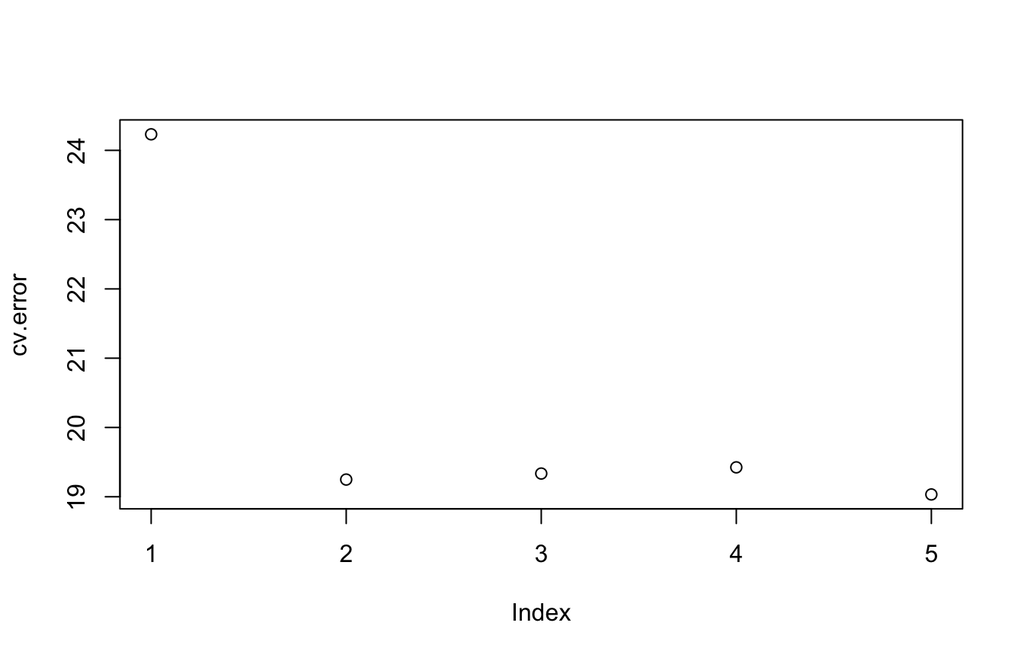

```r
cv.error=rep(0,5)
for (i in 1:5){
 glm.fit=glm(mpg~poly(horsepower,i),data=Auto)
 cv.error[i]=cv.glm(Auto,glm.fit)$delta[1]
 }
plot(cv.error)
```

## 5 k-Fold Cross-Validation

The `cv.glm()` function can also be used to implement k-fold CV. We set a seed and initialize a vector in which we will store the CV errors corresponding to the polynomial fits of orders one to ten.

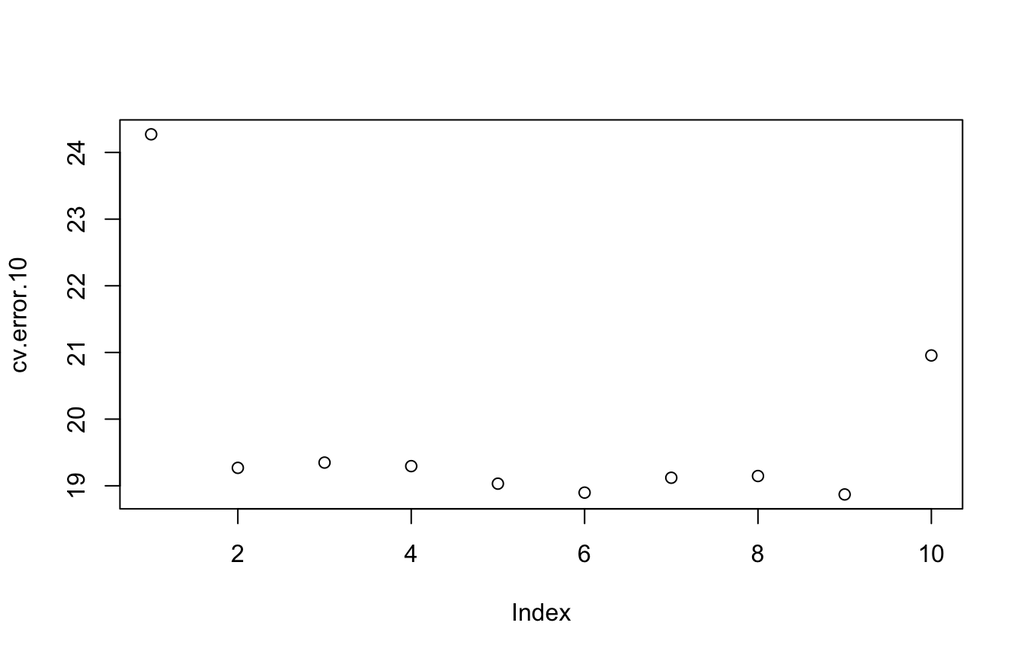

```r
set.seed(17)
cv.error.10=rep(0,10)
for (i in 1:10){
 glm.fit=glm(mpg~poly(horsepower,i),data=Auto)
 cv.error.10[i]=cv.glm(Auto,glm.fit,K=10)$delta[1]
 }
plot(cv.error.10)
```

Finally, we summarize the quadratic model.

```r
glm.fit2=glm(mpg~poly(horsepower,2),data=Auto)
summary(glm.fit2)
```

```
##
## Call:
## glm(formula = mpg ~ poly(horsepower, 2), data = Auto)
##
## Coefficients:
##                       Estimate Std. Error t value Pr(>|t|)
## (Intercept)            23.4459     0.2209  106.13   <2e-16 ***
## poly(horsepower, 2)1 -120.1377     4.3739  -27.47   <2e-16 ***
## poly(horsepower, 2)2   44.0895     4.3739   10.08   <2e-16 ***
## ---
## Signif. codes:  0 '***' 0.001 '**' 0.01 '*' 0.05 '.' 0.1 ' ' 1
##
## (Dispersion parameter for gaussian family taken to be 19.13118)
##
##     Null deviance: 23819  on 391  degrees of freedom
## Residual deviance:  7442  on 389  degrees of freedom
## AIC: 2274.4
##
## Number of Fisher Scoring iterations: 2
```

## 6 Model Complexity and Variance

More flexible models typically have higher variance: small changes in the training data can produce larger changes in the fitted model. To illustrate this, we fit a linear model and a tenth-degree polynomial using two different training sets.

We first standardize horsepower to improve the numerical stability of the polynomial regression.

```r
horsepower.mean = mean(Auto$horsepower)
horsepower.sd = sd(Auto$horsepower)

Auto$horsepower.std =
  (Auto$horsepower - horsepower.mean) / horsepower.sd
```

We construct two training sets, each containing half of the observations.

```r
set.seed(1)
train.1 = sample(seq_len(nrow(Auto)), nrow(Auto) / 2)

set.seed(2)
train.2 = sample(seq_len(nrow(Auto)), nrow(Auto) / 2)
```

We fit a linear regression and a tenth-degree polynomial regression to each training set.

```r
linear.fit.1 = lm(
  mpg ~ horsepower.std,
  data = Auto,
  subset = train.1
)

linear.fit.2 = lm(
  mpg ~ horsepower.std,
  data = Auto,
  subset = train.2
)

poly.fit.1 = lm(
  mpg ~ poly(horsepower.std, 10, raw = TRUE),
  data = Auto,
  subset = train.1
)

poly.fit.2 = lm(
  mpg ~ poly(horsepower.std, 10, raw = TRUE),
  data = Auto,
  subset = train.2
)
```

We first compare the coefficients of the two linear models.

```r
linear.coefs = data.frame(
  term = c("Intercept", "Horsepower"),
  training_set_1 = coef(linear.fit.1),
  training_set_2 = coef(linear.fit.2)
)

linear.coefs$absolute_difference =
  abs(linear.coefs$training_set_1 -
        linear.coefs$training_set_2)

knitr::kable(
  linear.coefs,
  digits = 3,
  row.names = FALSE
)
```

| term | training_set_1 | training_set_2 | absolute_difference |
| --- | --- | --- | --- |
| Intercept | 23.559 | 23.219 | 0.341 |
| Horsepower | -6.530 | -5.825 | 0.706 |

We can similarly compare the coefficients of the tenth-degree polynomial models.

```r
poly.coefs = data.frame(
  term = c("Intercept", paste0("Degree ", 1:10)),
  training_set_1 = coef(poly.fit.1),
  training_set_2 = coef(poly.fit.2)
)

poly.coefs$absolute_difference =
  abs(poly.coefs$training_set_1 -
        poly.coefs$training_set_2)

knitr::kable(
  poly.coefs,
  digits = 3,
  row.names = FALSE
)
```

| term | training_set_1 | training_set_2 | absolute_difference |
| --- | --- | --- | --- |
| Intercept | 20.180 | 21.266 | 1.086 |
| Degree 1 | -5.868 | -4.704 | 1.164 |
| Degree 2 | 14.362 | 1.997 | 12.365 |
| Degree 3 | -5.705 | -7.074 | 1.369 |
| Degree 4 | -17.729 | 1.103 | 18.832 |
| Degree 5 | 5.539 | 4.271 | 1.268 |
| Degree 6 | 9.778 | -0.537 | 10.316 |
| Degree 7 | -3.718 | -1.073 | 2.645 |
| Degree 8 | -1.730 | 0.002 | 1.733 |
| Degree 9 | 1.036 | 0.208 | 0.828 |
| Degree 10 | -0.134 | -0.039 | 0.095 |

Because polynomial coefficients can be difficult to interpret directly, we also compare the fitted regression curves.

```r
horsepower.grid = seq(
  min(Auto$horsepower),
  max(Auto$horsepower),
  length.out = 300
)

prediction.grid = data.frame(
  horsepower.std =
    (horsepower.grid - horsepower.mean) / horsepower.sd
)

prediction.curves = rbind(
  data.frame(
    horsepower = horsepower.grid,
    predicted_mpg = predict(linear.fit.1, prediction.grid),
    model = "Linear model",
    training_set = "Training set 1"
  ),
  data.frame(
    horsepower = horsepower.grid,
    predicted_mpg = predict(linear.fit.2, prediction.grid),
    model = "Linear model",
    training_set = "Training set 2"
  ),
  data.frame(
    horsepower = horsepower.grid,
    predicted_mpg = predict(poly.fit.1, prediction.grid),
    model = "Degree-10 polynomial",
    training_set = "Training set 1"
  ),
  data.frame(
    horsepower = horsepower.grid,
    predicted_mpg = predict(poly.fit.2, prediction.grid),
    model = "Degree-10 polynomial",
    training_set = "Training set 2"
  )
)
```

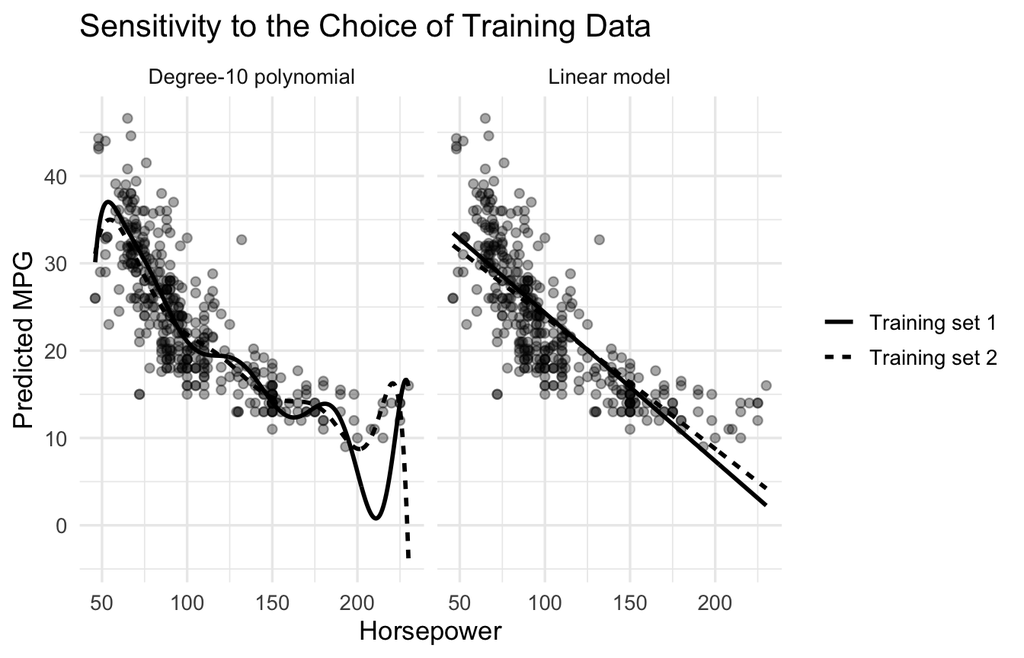

```r
ggplot(Auto, aes(x = horsepower, y = mpg)) +
  geom_point(alpha = 0.35) +
  geom_line(
    data = prediction.curves,
    aes(
      x = horsepower,
      y = predicted_mpg,
      linetype = training_set
    ),
    linewidth = 1,
    inherit.aes = FALSE
  ) +
  facet_wrap(~ model) +
  labs(
    title = "Sensitivity to the Choice of Training Data",
    x = "Horsepower",
    y = "Predicted MPG",
    linetype = NULL
  )
```

Finally, we calculate the root mean squared difference between the fitted curves.

```r
linear.pred.1 = predict(linear.fit.1, prediction.grid)
linear.pred.2 = predict(linear.fit.2, prediction.grid)

poly.pred.1 = predict(poly.fit.1, prediction.grid)
poly.pred.2 = predict(poly.fit.2, prediction.grid)

fit.variability = data.frame(
  model = c(
    "Linear model",
    "Degree-10 polynomial"
  ),
  RMSE_between_fitted_curves = c(
    sqrt(mean((linear.pred.1 - linear.pred.2)^2)),
    sqrt(mean((poly.pred.1 - poly.pred.2)^2))
  )
)

knitr::kable(
  fit.variability,
  digits = 3,
  row.names = FALSE
)
```

| model | RMSE_between_fitted_curves |
| --- | --- |
| Linear model | 1.015 |
| Degree-10 polynomial | 3.921 |

The tenth-degree polynomial generally changes more substantially across the two training sets. This illustrates the higher variance of flexible models: their fitted predictions are more sensitive to which observations are included in the training data.